# Class 2 - Wrangle Data

May 29, 2020

## Let’s Get Started

- [Cheat Sheet for this class](https://github.com/rstudio/cheatsheets/raw/master/data-transformation.pdf)
- Start by Downloading the necessary packages
- We will need `dplyr`, `ggplot2`, `gapminder` and `tidyr`
  - Can you remember how we load libraries?

## Load Libraries

- We will be using the gapminder dataset
  - Remember you can do `help()` to find out more about the dataset

```r
#install.packages('dplyr')
#install.packages('ggplot2')
#install.packages('gapminder')
#install.packages('tidyr')
library(dplyr)
library(ggplot2)
library(gapminder)
library(tidyr)
```

```r
# Or we can use pacman
library(pacman)
p_load(dplyr, ggplot2, gapminder, tidyr)
```

## Recap of Basic R Verbs

```r
# Print the first few rows of the data
head(gapminder)
```

```
## # A tibble: 6 x 6
##   country     continent  year lifeExp      pop gdpPercap
##   <fct>       <fct>     <int>   <dbl>    <int>     <dbl>
## 1 Afghanistan Asia       1952    28.8  8425333      779.
## 2 Afghanistan Asia       1957    30.3  9240934      821.
## 3 Afghanistan Asia       1962    32.0 10267083      853.
## 4 Afghanistan Asia       1967    34.0 11537966      836.
## 5 Afghanistan Asia       1972    36.1 13079460      740.
## 6 Afghanistan Asia       1977    38.4 14880372      786.
```

```r
# Get the shape of the data
dim(gapminder)
```

```
## [1] 1704    6
```

## Data Transformation with `dplyr`

- `filter()` - remove rows according to a criteria
- `select()` - select columns by name
- `mutate()` - calculate new column variables by manipulating data
- `arrange()` - sort data by columns
- `summarize()` - compute summary statistics

## THE PIPE %>%

- `%>%` is called the pipe operator
- It helps us to pass on a dataframe to a certain function / operation

```r
gapminder %>%
  head(3)
```

```
## # A tibble: 3 x 6
##   country     continent  year lifeExp      pop gdpPercap
##   <fct>       <fct>     <int>   <dbl>    <int>     <dbl>
## 1 Afghanistan Asia       1952    28.8  8425333      779.
## 2 Afghanistan Asia       1957    30.3  9240934      821.
## 3 Afghanistan Asia       1962    32.0 10267083      853.
```

## Filtering Data

- Row-wise filtering
  - Logical filtering
  - e.g. `==`, `!=`, `|`, `&`, `isna()`, `>`, `<`, `>=`

```r
# Filter for Australia and year equals to 2007
gapminder %>%
  filter(country == 'Australia' & year == 2007)
```

```
## # A tibble: 1 x 6
##   country   continent  year lifeExp      pop gdpPercap
##   <fct>     <fct>     <int>   <dbl>    <int>     <dbl>
## 1 Australia Oceania    2007    81.2 20434176    34435.
```

## Filtering Data

- Across multiple columns

```r
# Filter for African continent and population greater than 80 million
gapminder %>%
  filter(continent == "Africa", # add a comma
         pop > 80000000)
```

```
## # A tibble: 6 x 6
##   country continent  year lifeExp       pop gdpPercap
##   <fct>   <fct>     <int>   <dbl>     <int>     <dbl>
## 1 Egypt   Africa     2007    71.3  80264543     5581.
## 2 Nigeria Africa     1987    46.9  81551520     1385.
## 3 Nigeria Africa     1992    47.5  93364244     1620.
## 4 Nigeria Africa     1997    47.5 106207839     1625.
## 5 Nigeria Africa     2002    46.6 119901274     1615.
## 6 Nigeria Africa     2007    46.9 135031164     2014.
```

## Try out `filter`

- Now you try!
- Can you filter the data for either ‘Singapore’ or ‘Hong Kong, China’ and for the years after 2000
- Can you filter the data for ‘Oceania’ continent but don’t include Australia

## Try out `filter`

- Did you get it right?

```r
gapminder %>%
  filter(country == 'Singapore' | country == 'Hong Kong, China',
         year > 2000)
```

```
## # A tibble: 4 x 6
##   country          continent  year lifeExp     pop gdpPercap
##   <fct>            <fct>     <int>   <dbl>   <int>     <dbl>
## 1 Hong Kong, China Asia       2002    81.5 6762476    30209.
## 2 Hong Kong, China Asia       2007    82.2 6980412    39725.
## 3 Singapore        Asia       2002    78.8 4197776    36023.
## 4 Singapore        Asia       2007    80.0 4553009    47143.
```

## Try out `filter`

- Did you get it right?

```r
gapminder %>%
  filter(continent == 'Oceania',
         country != 'Australia') %>% head(4)
```

```
## # A tibble: 4 x 6
##   country     continent  year lifeExp     pop gdpPercap
##   <fct>       <fct>     <int>   <dbl>   <int>     <dbl>
## 1 New Zealand Oceania    1952    69.4 1994794    10557.
## 2 New Zealand Oceania    1957    70.3 2229407    12247.
## 3 New Zealand Oceania    1962    71.2 2488550    13176.
## 4 New Zealand Oceania    1967    71.5 2728150    14464.
```

## Selecting Columns

```r
# Select single column
gapminder %>%
  select(year) %>%
  head(5)
```

```
## # A tibble: 5 x 1
##    year
##   <int>
## 1  1952
## 2  1957
## 3  1962
## 4  1967
## 5  1972
```

## Selecting Multiple Columns

```r
# Select 2 columns
gapminder %>%
  select(continent, pop) %>%
  head()
```

```
## # A tibble: 6 x 2
##   continent      pop
##   <fct>        <int>
## 1 Asia       8425333
## 2 Asia       9240934
## 3 Asia      10267083
## 4 Asia      11537966
## 5 Asia      13079460
## 6 Asia      14880372
```

## Selecting Multiple Columns

```r
# Select all but Year
gapminder %>%
  select(-year) %>%
  head(3)
```

```
## # A tibble: 3 x 5
##   country     continent lifeExp      pop gdpPercap
##   <fct>       <fct>       <dbl>    <int>     <dbl>
## 1 Afghanistan Asia         28.8  8425333      779.
## 2 Afghanistan Asia         30.3  9240934      821.
## 3 Afghanistan Asia         32.0 10267083      853.
```

## Selecting columns by name

```r
# select by column name
gapminder['continent'] %>% head(3)
```

```
## # A tibble: 3 x 1
##   continent
##   <fct>
## 1 Asia
## 2 Asia
## 3 Asia
```

## Selecting columns by index

```r
# 2nd column from the left
gapminder[, 2] %>% head(3)
```

```
## # A tibble: 3 x 1
##   continent
##   <fct>
## 1 Asia
## 2 Asia
## 3 Asia
```

## Selecting rows by index

```r
# select first 5 rows
gapminder[1:5, ]
```

```
## # A tibble: 5 x 6
##   country     continent  year lifeExp      pop gdpPercap
##   <fct>       <fct>     <int>   <dbl>    <int>     <dbl>
## 1 Afghanistan Asia       1952    28.8  8425333      779.
## 2 Afghanistan Asia       1957    30.3  9240934      821.
## 3 Afghanistan Asia       1962    32.0 10267083      853.
## 4 Afghanistan Asia       1967    34.0 11537966      836.
## 5 Afghanistan Asia       1972    36.1 13079460      740.
```

## Selecting Columns

- Now you try!
- Select only the `year` and `lifeExp` columns for the first 3 rows of the gapminder data

## Try out `select`

- Did you get it right?

```r
gapminder %>%
  select(year, lifeExp) %>%
  head(3)
```

```
## # A tibble: 3 x 2
##    year lifeExp
##   <int>   <dbl>
## 1  1952    28.8
## 2  1957    30.3
## 3  1962    32.0
```

## Select

- `starts_with()`: starts with a prefix
- `ends_with()`: ends with a prefix
- `contains()`: contains a literal string
- `matches()`: matches a regular expression
- `num_range()`: a numerical range like x01, x02, x03.
- `one_of()`: variables in character vector.
- `everything()`: all variables.

## Use `mutate` to create new columns

- Calculate a new variable based on other variables
  - E.g. we want to get GDP (in million), which is `pop` * `gdpPercap` / 1000000

```r
# Create gdp column
gapminder %>%
  mutate(gdp = round(pop * gdpPercap / 1000000, 1)) %>% # Round to 1 decimal place
  filter(country == 'Japan') %>%
  head()
```

```
## # A tibble: 6 x 7
##   country continent  year lifeExp       pop gdpPercap      gdp
##   <fct>   <fct>     <int>   <dbl>     <int>     <dbl>    <dbl>
## 1 Japan   Asia       1952    63.0  86459025     3217.  278135.
## 2 Japan   Asia       1957    65.5  91563009     4318.  395341.
## 3 Japan   Asia       1962    68.7  95831757     6577.  630252.
## 4 Japan   Asia       1967    71.4 100825279     9848.  992906
## 5 Japan   Asia       1972    73.4 107188273    14779. 1584113.
## 6 Japan   Asia       1977    75.4 113872473    16610. 1891465.
```

## Try out `mutate`

- Can you create a new column called `gdpPercap_rounded` that rounds gdpPercap to the nearest whole number?

## Try out `mutate`

- Did you get it?

```r
gapminder %>%
  mutate(gdpPercap_rounded = round(gdpPercap)) %>%
  head(3)
```

```
## # A tibble: 3 x 7
##   country     continent  year lifeExp      pop gdpPercap gdpPercap_rounded
##   <fct>       <fct>     <int>   <dbl>    <int>     <dbl>             <dbl>
## 1 Afghanistan Asia       1952    28.8  8425333      779.               779
## 2 Afghanistan Asia       1957    30.3  9240934      821.               821
## 3 Afghanistan Asia       1962    32.0 10267083      853.               853
```

## Use `summarize` to calculate data summaries such as means and standard deviations

There are several useful functions that can be used with `summarize()`:

- Center: `mean()`, `median()`
- Spread: `sd()`, `IQR()`
- Range: `min()`, `max()`, `quantile()`
- Position: `first()`, `last()`, `nth()`
- Count: `n()`, `n_distinct()`
- Logical: `any()`, `all()`

## Use `summarize` and `filter` to calculate the average lifeExp globally

```r
gapminder %>%
  filter(year == 1952) %>%
  summarize(mean(lifeExp))
```

```
## # A tibble: 1 x 1
##   `mean(lifeExp)`
##             <dbl>
## 1            49.1
```

```r
gapminder %>%
  group_by(country) %>%
  summarize(mean(lifeExp)) %>%
  head()
```

```
## # A tibble: 6 x 2
##   country     `mean(lifeExp)`
##   <fct>                 <dbl>
## 1 Afghanistan            37.5
## 2 Albania                68.4
## 3 Algeria                59.0
## 4 Angola                 37.9
## 5 Argentina              69.1
## 6 Australia              74.7
```

## Try out `summarize`

- Find out how the average `gdpPercap` of the ENTIRE world has increased or decreased over time

## Try out `summarize`

```r
gapminder %>%
  group_by(year) %>%
  summarize(mean(gdpPercap))
```

```
## # A tibble: 12 x 2
##     year `mean(gdpPercap)`
##    <int>             <dbl>
##  1  1952             3725.
##  2  1957             4299.
##  3  1962             4726.
##  4  1967             5484.
##  5  1972             6770.
##  6  1977             7313.
##  7  1982             7519.
##  8  1987             7901.
##  9  1992             8159.
## 10  1997             9090.
## 11  2002             9918.
## 12  2007            11680.
```

## Using `distinct` to find unique values

- This is useful for removing duplicated rows or multiple identical rows

```r
# Find unique continent
gapminder %>%
  distinct(continent)
```

```
## # A tibble: 5 x 1
##   continent
##   <fct>
## 1 Asia
## 2 Europe
## 3 Africa
## 4 Americas
## 5 Oceania
```

## Using `distinct` and `count` to calculate number of unique values

- We can also use it in this way to count the number of unique values in the column, e.g. countries

```r
# Find out how many countries are there in the dataset
gapminder %>%
  distinct(country) %>%
  count()
```

```
## # A tibble: 1 x 1
##       n
##   <int>
## 1   142
```

## Use `table` to tabulate / count unique values

```r
# Find out how many countries are there in each continent
gapminder %>%
  filter(year == 2007) %>%
  group_by(continent) %>%
  select(continent) %>%
  table()
```

```
## .
##   Africa Americas     Asia   Europe  Oceania
##       52       25       33       30        2
```

## Use `prop.table` to tabulate / count unique values

- `prop.table()` gives us the percentage instead of the count

```r
# Find out how many countries are there in each continent
gapminder %>%
  filter(year == 2007) %>%
  group_by(continent) %>%
  select(continent) %>%
  table() %>%
  prop.table() %>%
  round(2)
```

```
## .
##   Africa Americas     Asia   Europe  Oceania
##     0.37     0.18     0.23     0.21     0.01
```

## Another way to do this is to use `unique`

```r
unique(gapminder['continent'])
```

```
## # A tibble: 5 x 1
##   continent
##   <fct>
## 1 Asia
## 2 Europe
## 3 Africa
## 4 Americas
## 5 Oceania
```

## Sorting the Data

- Sort data using the `arrange` verb

```r
# the default for arrange is increasing
gapminder %>%
  arrange(gdpPercap) %>% head()
```

```
## # A tibble: 6 x 6
##   country          continent  year lifeExp      pop gdpPercap
##   <fct>            <fct>     <int>   <dbl>    <int>     <dbl>
## 1 Congo, Dem. Rep. Africa     2002    45.0 55379852      241.
## 2 Congo, Dem. Rep. Africa     2007    46.5 64606759      278.
## 3 Lesotho          Africa     1952    42.1   748747      299.
## 4 Guinea-Bissau    Africa     1952    32.5   580653      300.
## 5 Congo, Dem. Rep. Africa     1997    42.6 47798986      312.
## 6 Eritrea          Africa     1952    35.9  1438760      329.
```

## Sorting the Data

```r
# To change to decreasing, use desc
gapminder %>%
  arrange(desc(gdpPercap)) %>% head()
```

```
## # A tibble: 6 x 6
##   country continent  year lifeExp     pop gdpPercap
##   <fct>   <fct>     <int>   <dbl>   <int>     <dbl>
## 1 Kuwait  Asia       1957    58.0  212846   113523.
## 2 Kuwait  Asia       1972    67.7  841934   109348.
## 3 Kuwait  Asia       1952    55.6  160000   108382.
## 4 Kuwait  Asia       1962    60.5  358266    95458.
## 5 Kuwait  Asia       1967    64.6  575003    80895.
## 6 Kuwait  Asia       1977    69.3 1140357    59265.
```

## Try out `sort`

- Sort the data in descending order of `pop`

## Try out `sort`

```r
gapminder %>%
  arrange(desc(pop)) %>%
  head()
```

```
## # A tibble: 6 x 6
##   country continent  year lifeExp        pop gdpPercap
##   <fct>   <fct>     <int>   <dbl>      <int>     <dbl>
## 1 China   Asia       2007    73.0 1318683096     4959.
## 2 China   Asia       2002    72.0 1280400000     3119.
## 3 China   Asia       1997    70.4 1230075000     2289.
## 4 China   Asia       1992    68.7 1164970000     1656.
## 5 India   Asia       2007    64.7 1110396331     2452.
## 6 China   Asia       1987    67.3 1084035000     1379.
```

## Reshaping Data

- Not as commonly used but still important to know incase you need to change the format of the data

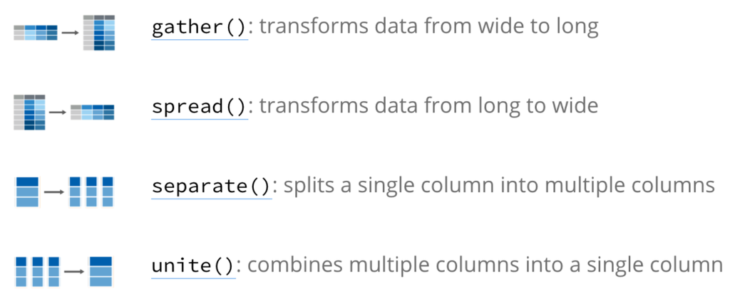

## Reshape the data with `spread`

- `spread` transforms the data from long format to wide format
- There are 2 parameters in the `spread` verb
  - the first is the key (the column values to convert into multiple columns)
  - the second is the value (the single column values to covert to multiple columns’ values)

## Reshape the data with `spread`

Before:

```r
gapminder %>%
  select(country, year, pop) %>% head() # year is the key, pop is the value
```

```
## # A tibble: 6 x 3
##   country      year      pop
##   <fct>       <int>    <int>
## 1 Afghanistan  1952  8425333
## 2 Afghanistan  1957  9240934
## 3 Afghanistan  1962 10267083
## 4 Afghanistan  1967 11537966
## 5 Afghanistan  1972 13079460
## 6 Afghanistan  1977 14880372
```

## Reshape the data with `spread`

After:

```r
gapminder %>%
  select(country, year, pop) %>%
  spread(key = year, value = pop) %>% # key is the year, value is the population
  head()
```

```
## # A tibble: 6 x 13
##   country `1952` `1957` `1962` `1967` `1972` `1977` `1982` `1987` `1992` `1997`
##   <fct>    <int>  <int>  <int>  <int>  <int>  <int>  <int>  <int>  <int>  <int>
## 1 Afghan… 8.43e6 9.24e6 1.03e7 1.15e7 1.31e7 1.49e7 1.29e7 1.39e7 1.63e7 2.22e7
## 2 Albania 1.28e6 1.48e6 1.73e6 1.98e6 2.26e6 2.51e6 2.78e6 3.08e6 3.33e6 3.43e6
## 3 Algeria 9.28e6 1.03e7 1.10e7 1.28e7 1.48e7 1.72e7 2.00e7 2.33e7 2.63e7 2.91e7
## 4 Angola  4.23e6 4.56e6 4.83e6 5.25e6 5.89e6 6.16e6 7.02e6 7.87e6 8.74e6 9.88e6
## 5 Argent… 1.79e7 1.96e7 2.13e7 2.29e7 2.48e7 2.70e7 2.93e7 3.16e7 3.40e7 3.62e7
## 6 Austra… 8.69e6 9.71e6 1.08e7 1.19e7 1.32e7 1.41e7 1.52e7 1.63e7 1.75e7 1.86e7
## # … with 2 more variables: `2002` <int>, `2007` <int>
```

## Reshape the data with `gather`

- `gather` does the reverse of spread
- Check out the documentation of the verb or look at the cheatsheet for example

## Join columns together with `unite`

- Useful for joining string columns together
  - col states the name of the new merged column
  - sep is the separator to use between merged values

```r
# Create a new column called location
gapminder %>%
  unite(col = location, country, continent, sep = ", ") %>%
  head()
```

```
## # A tibble: 6 x 5
##   location           year lifeExp      pop gdpPercap
##   <chr>             <int>   <dbl>    <int>     <dbl>
## 1 Afghanistan, Asia  1952    28.8  8425333      779.
## 2 Afghanistan, Asia  1957    30.3  9240934      821.
## 3 Afghanistan, Asia  1962    32.0 10267083      853.
## 4 Afghanistan, Asia  1967    34.0 11537966      836.
## 5 Afghanistan, Asia  1972    36.1 13079460      740.
## 6 Afghanistan, Asia  1977    38.4 14880372      786.
```

## Split columns with `separate`

- `separate` does the opposite of `unite`
- Check out the documentation of the verb or look at the cheatsheet for example

## Joining and merging data together

```r
# Download red wine and white wine dataset
p_load(data.table)
red_wine <- fread('https://archive.ics.uci.edu/ml/machine-learning-databases/wine-quality/winequality-red.csv',  sep = ';') %>% head(100) %>% mutate(wine = "red")
white_wine <- fread('https://archive.ics.uci.edu/ml/machine-learning-databases/wine-quality/winequality-white.csv', sep = ';') %>% head(100) %>% mutate(wine = "white")
```

## Joining and merging datasets together

- Let’s say we have 2 datasets that we want to merge together

```r
red_wine %>% head(3)
```

```
##   fixed acidity volatile acidity citric acid residual sugar chlorides
## 1           7.4             0.70        0.00            1.9     0.076
## 2           7.8             0.88        0.00            2.6     0.098
## 3           7.8             0.76        0.04            2.3     0.092
##   free sulfur dioxide total sulfur dioxide density   pH sulphates alcohol
## 1                  11                   34  0.9978 3.51      0.56     9.4
## 2                  25                   67  0.9968 3.20      0.68     9.8
## 3                  15                   54  0.9970 3.26      0.65     9.8
##   quality wine
## 1       5  red
## 2       5  red
## 3       5  red
```

## Joining and merging datasets together

- Let’s say we have 2 datasets that we want to merge together

```r
white_wine %>% head(3)
```

```
##   fixed acidity volatile acidity citric acid residual sugar chlorides
## 1           7.0             0.27        0.36           20.7     0.045
## 2           6.3             0.30        0.34            1.6     0.049
## 3           8.1             0.28        0.40            6.9     0.050
##   free sulfur dioxide total sulfur dioxide density   pH sulphates alcohol
## 1                  45                  170  1.0010 3.00      0.45     8.8
## 2                  14                  132  0.9940 3.30      0.49     9.5
## 3                  30                   97  0.9951 3.26      0.44    10.1
##   quality  wine
## 1       6 white
## 2       6 white
## 3       6 white
```

## Joining and merging datasets together

- To join them by row, i.e join to the bottom, we will use `rbind`
  - To join by column, we will use `cbind`

```r
rbind(red_wine, white_wine)
```

```
##     fixed acidity volatile acidity citric acid residual sugar chlorides
## 1             7.4            0.700        0.00           1.90     0.076
## 2             7.8            0.880        0.00           2.60     0.098
## 3             7.8            0.760        0.04           2.30     0.092
## 4            11.2            0.280        0.56           1.90     0.075
## 5             7.4            0.700        0.00           1.90     0.076
## 6             7.4            0.660        0.00           1.80     0.075
## 7             7.9            0.600        0.06           1.60     0.069
## 8             7.3            0.650        0.00           1.20     0.065
## 9             7.8            0.580        0.02           2.00     0.073
## 10            7.5            0.500        0.36           6.10     0.071
## 11            6.7            0.580        0.08           1.80     0.097
## 12            7.5            0.500        0.36           6.10     0.071
## 13            5.6            0.615        0.00           1.60     0.089
## 14            7.8            0.610        0.29           1.60     0.114
```

[output cut: 588 more lines]

## Joining and merging datasets

We can also use:

- `merge` - when you want all rows (similar to `full_join`)
- `inner_join` - only select rows that match
- `left_join`
- `right_join`
- `full_join` - when you want all rows
- `anti_join`

## Recap of `dplyr`

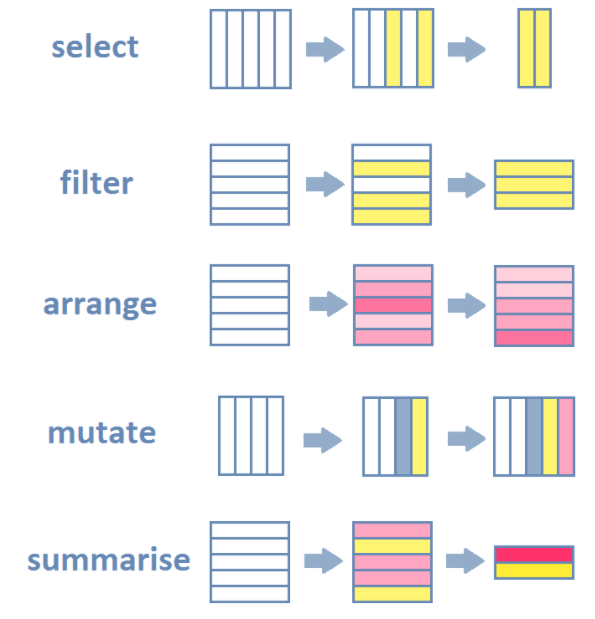

## Bonus {.smaller}

- Make fancy tables with kableExtra

```r
# Load kableExtra package
p_load(kableExtra)
```

```r
# Kable
gapminder %>%
  filter(year == 2007) %>%
  group_by(continent) %>%
  select(-c(country, year)) %>%
  summarise_all(funs(mean)) %>%
  kable() %>%
  kable_styling("striped")
```

| continent | lifeExp | pop | gdpPercap |
| --- | --- | --- | --- |
| Africa | 54.80604 | 17875763 | 3089.033 |
| Americas | 73.60812 | 35954847 | 11003.032 |
| Asia | 70.72848 | 115513752 | 12473.027 |
| Europe | 77.64860 | 19536618 | 25054.482 |
| Oceania | 80.71950 | 12274974 | 29810.188 |

```r
# looks much better on a normal pdf or markdown output than slides
```

## Bonus

- Make interactive tables on HTML documents with `DT` package
- For more information, check the documentation [here](https://rstudio.github.io/DT/)

```r
# Load DT package
p_load(DT)
datatable(gapminder, filter = 'top', options = list(pageLength = 5, autoWidth = TRUE))
```

|  | country | continent | year | lifeExp | pop | gdpPercap |
| --- | --- | --- | --- | --- | --- | --- |
| 1 | Afghanistan | Asia | 1952 | 28.801 | 8425333 | 779.4453145 |
| 2 | Afghanistan | Asia | 1957 | 30.332 | 9240934 | 820.8530296 |
| 3 | Afghanistan | Asia | 1962 | 31.997 | 10267083 | 853.10071 |
| 4 | Afghanistan | Asia | 1967 | 34.02 | 11537966 | 836.1971382 |
| 5 | Afghanistan | Asia | 1972 | 36.088 | 13079460 | 739.9811058 |
| 6 | Afghanistan | Asia | 1977 | 38.438 | 14880372 | 786.11336 |
| 7 | Afghanistan | Asia | 1982 | 39.854 | 12881816 | 978.0114388 |
| 8 | Afghanistan | Asia | 1987 | 40.822 | 13867957 | 852.3959448 |
| 9 | Afghanistan | Asia | 1992 | 41.674 | 16317921 | 649.3413952 |
| 10 | Afghanistan | Asia | 1997 | 41.763 | 22227415 | 635.341351 |

[output cut: 1694 more lines]